# Relatedness Between Larvae and Adults

Alan Couch

Fri May 06 1:49:19 PM 2016

```
## Loading project configuration
```

```
## Autoloading helper functions
```

```
##  Running helper script: funRel.R
```

```
## Autoloading cache
```

```
## Autoloading data
```

```
##  Loading data set: DARTallIdentifiers
```

```
##  Loading data set: qslAllLarvaInfo
```

```
##  Loading data set: qslAllLarvaInfo2015
```

```
##  Loading data set: Report.DMac15.1861
```

```
## Munging data
```

```
##  Running preprocessing script: 01MungeGeneticsData.R
```

```
##  Running preprocessing script: 02MungeLarvaSnpsByYears.R
```

```
##  Running preprocessing script: 03MungeLarvaSnpsByYearCombos.R
```

Because the genetic diversity is low, and there is likely inbreeding among the extant population, the inbreeding mode for ‘related’ is set to on. This makes calculations much slower, so estimators are not compared for combinations of larvae/adults or years.

# 2011 Larval with Adult Relatedness

```r
#read file in
elAdLarv<-cbind(ellarvalPeeliSnps,adultPeeliSnps)
df<-elAdLarv; main<-"2011 Larval snps with Adults"
df<-df[-c(1:4),]
```

```r
require(digest)
for (i in 1:length(df$X..2)) {
    df$unique[i] <- digest(df$X..2[i], algo = "xxhash32", seed = 1)
}
df <- cbind(df$unique, df)
names(df)[names(df) == "df$unique"] <- "allele"
df$unique <- NULL
df[1:10, c(1, 4)]
```

```
##       allele                                                                  X..2
## X5  a43f66cc                                                        AlleleSequence
## X6  127f06ec TGCAGGAGTCACGTTTCTCTCCCAAAACTCCCCTTAAGCTAAAAAACGTATAAATGAGAGCGTCAGCTA
## X7  756ac72f TGCAGGAGTCACGTTTCTCTCCCAAAACTCCCCTTAAGCTAAAAAACGTATAAATGAGAGTGTCAGCTA
## X8  648bd84a TGCAGAAATAAAGAACTTATTTTCAACCAACATGTCTTGTGATACCAAAGTTCTTTGGCCGCTATGTGC
## X9  9e1e8afc TGCAGAAATAAAGAATTTATTTTCAACCAACATGTCTTGTGATACCAAAGTTCTTTGGCCGCTATGTGC
## X10 d1899d1e TGCAGTGCTAATGCAGTTCGGAGGGCTTCTGCAATGCCTGTAAATGTGTACATGAGTATGTTTGTACAC
## X11 1beb420d TGCAGTGCTAATGCAGTTCGGGGGGCTTCTGCAATGCCTGTAAATGTGTACATGAGTATGTTTGTACAC
## X12 6a38a8f3 TGCAGTTGGACCCTTTGGTTGCCATTAGCCACGCTATCGTTTACTCCAGCTTTCCAAAACTGGGAAAGC
## X13 2630df0b TGCAGTTGGACCCTTTGGTTGCCATTAGCCACGCTATCGTTTACTCCAGCTTTCCAAAACTGGAAAAGC
## X14 c58a8999 TGCAGTTAACTCACCAAACTTTACTTTCCCACATTCCTAAAACCCCAGGCATTTGCATTATTTGAACCC
```

```r
df2 <- df
df2[2:18] <- list(NULL)
df2 <- setNames(data.frame(t(df2[, -1])), df2[, 1])
rownames(df2) <- df2[, 1]
fishID <- df2[, 1]
df2[, 1] <- NULL
colnames(df2) <- paste("X", colnames(df2), sep = "")
df2 <- as.data.frame(apply(df2, 2, function(x) gsub("\\s+", "", x)))
indx <- sapply(df2, is.factor)
df2[indx] <- lapply(df2[indx], function(x) as.numeric(as.character(x)))
rm(indx)
x <- df2
library(data.table)
setDT(x)
for (j in seq_along(x)) {
    set(x, i = which(x[[j]] == 1 & !is.na(x[[j]])), j = j, value = j)
}
d1 <- data.frame(x)
rm(x)
rm(i)
rm(j)
d1.lst <- lapply(seq(1, ncol(d1), by = 2), function(x) {
    return(d1[, x:(x + 1)])
})
d1.lst.fil <- lapply(d1.lst, function(x) {
    x[, 1][!is.na(x[, 1]) & x[, 1] == "0"] <- x[, 2][!is.na(x[, 1]) & x[, 1] == "0"]
    x[, 2][!is.na(x[, 2]) & x[, 2] == "0"] <- x[, 1][!is.na(x[, 2]) & x[, 2] == "0"]
    return(x)
})
df2 <- do.call(cbind, d1.lst.fil)
rm(d1)
rm(d1.lst)
rm(d1.lst.fil)
df2 <- cbind(fishID, df2)
rownames(df2) <- df2[, 1]
df2[, 1] <- NULL
write.table(df2[, 1:600], "outRelated.txt", sep = " ", col.names = FALSE, row.names = TRUE, quote = FALSE)
require(related)
input <- readgenotypedata("outRelated.txt")
input$nloci
```

```
## [1] 300
```

```r
input$nalleles
```

```
##   [1] 2 2 2 2 2 2 2 2 2 2 2 2 2 2 2 2 2 2 2 2 2 2 2 2 2 2 2 2 2 2 2 2 2 2 2 2 2 2 2 2 2 2 2 2 2 2 2 2 2 2 2 2 2 2 2 2 2 2 2 2 2 2 2 2 2 2 2 2 2 2 2 2 2 2 2 2 2 2 2 2 2 2 2 2 2 2 2 2 2 2 2 2 2 2 2 2 2
##  [98] 2 2 2 2 2 2 2 2 2 2 2 2 2 2 2 2 2 2 2 2 2 2 2 2 2 2 2 2 2 2 2 2 2 2 2 2 2 2 2 2 2 2 2 2 2 2 2 2 2 2 2 2 2 2 2 2 2 2 2 2 2 2 2 2 2 2 2 2 2 2 2 2 2 2 2 2 2 2 2 2 2 2 2 2 2 2 2 2 2 2 2 2 2 2 2 2 2
## [195] 2 2 2 2 2 2 2 2 2 2 2 2 2 2 2 2 2 2 2 2 2 2 2 2 2 2 2 2 2 2 2 2 2 2 2 2 2 2 2 2 2 2 2 2 2 2 2 2 2 2 2 2 2 2 2 2 2 2 2 2 2 2 2 2 2 2 2 2 2 2 2 2 2 2 2 2 2 2 2 2 2 2 2 2 2 2 2 2 2 2 2 2 2 2 2 2 2
## [292] 2 2 2 2 2 2 2 2 2
```

```r
input$ninds
```

```
## [1] 87
```

```r
output <- coancestry(input$gdata, allow.inbreeding = TRUE, dyadml = 2)
```

```
##    user  system elapsed
##  109.11    0.42  112.96
##
## Reading output files into data.frames... Done!
```

```r
head(output$relatedness)
```

```
##   pair.no ind1.id ind2.id group trioml wang lynchli lynchrd ritland quellergt dyadml
## 1       1      70      71  7071      0    0       0       0       0         0 0.0466
## 2       2      70      72  7072      0    0       0       0       0         0 0.2751
## 3       3      70      73  7073      0    0       0       0       0         0 0.3739
## 4       4      70      76  7076      0    0       0       0       0         0 0.0000
## 5       5      70      75  7075      0    0       0       0       0         0 0.2720
## 6       6      70      74  7074      0    0       0       0       0         0 0.1814
```

```r
head(output$inbreeding)
```

```
##   ind.id      LH      LR
## 1     70 -0.0294 -0.0310
## 2     71  0.0296  0.0297
## 3     72  0.1470  0.1536
## 4     73 -0.2545 -0.2489
## 5     76 -0.9423 -0.7201
## 6     75 -0.4386 -0.4233
```

```r
sim <- familysim(input$freqs, 100)
output2 <- coancestry(sim, wang = 1)
```

```
##    user  system elapsed
##  125.80   17.08  211.70
##
## Reading output files into data.frames... Done!
```

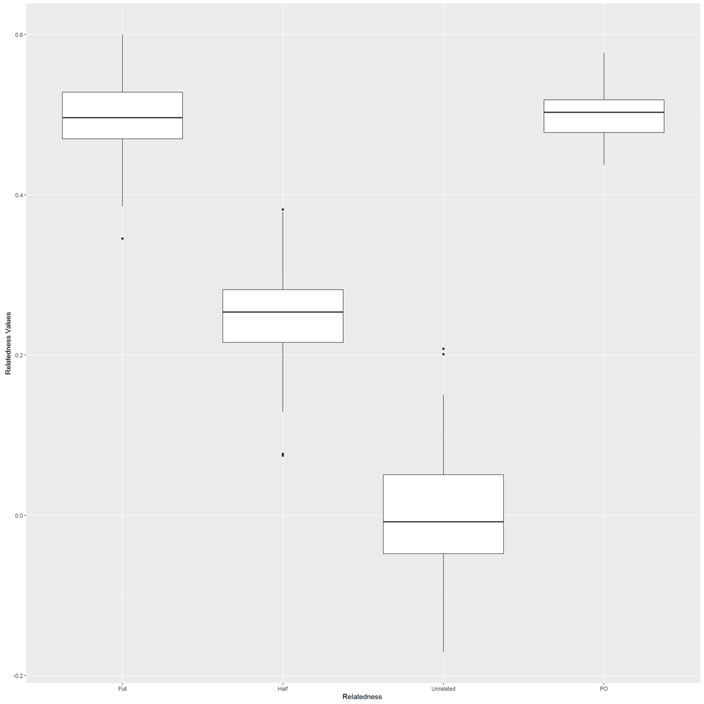

```r
simrel <- cleanuprvals(output2$relatedness, 100)
relvalues <- simrel[, 6]
label1 <- rep("PO", 100)
label2 <- rep(" Full ", 100)
label3 <- rep(" Half ", 100)
label4 <- rep(" Unrelated ", 100)
labels <- c(label1, label2, label3, label4)
qplot(as.factor(labels), relvalues, geom = "boxplot", ylab = " Relatedness Values ", xlab = "Relatedness ")
```

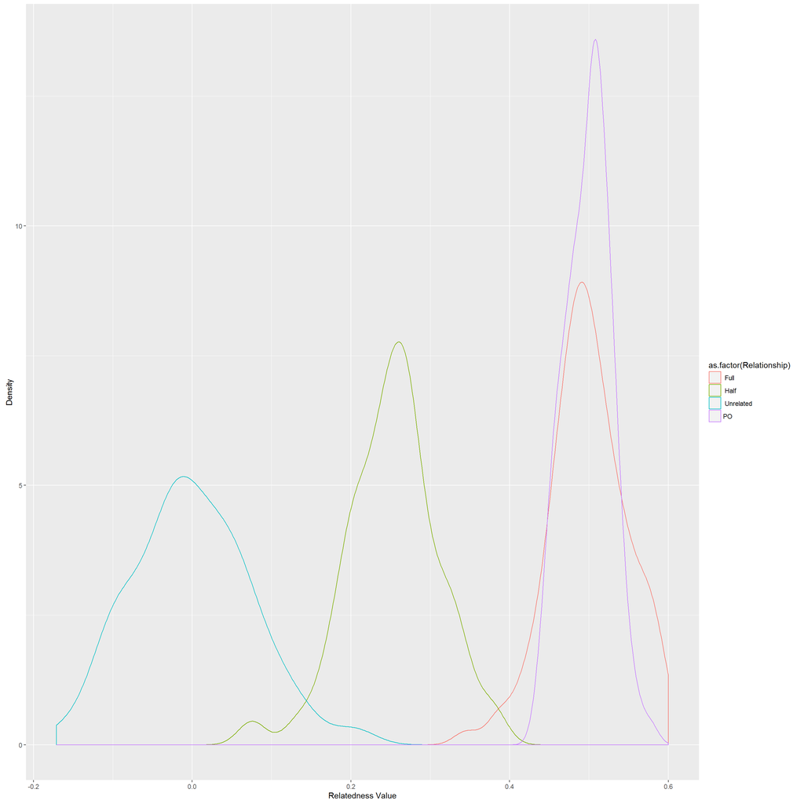

```r
Relationship <- labels
newdata <- as.data.frame(cbind(Relationship, relvalues))
newdata$relvalues <- as.numeric(as.character(newdata$relvalues))
qplot(relvalues, ..density.., data = newdata, geom = "density", colour = as.factor(Relationship), xlab = " Relatedness Value ", ylab = "Density")
```

So there are 300 loci being analysed. These are the first loci in the file ATM.

There are 2 alleles for each of these loci.

There are 87 individual fish in this set.

From the simulations of ‘known’ relationships we can choose cut off values for identifying relationships and colouring them in the matrix. In this case FS or PO above 0.4; HS 0.1-0.4; unrelated fish have a relatedness value below 0.15.

## Compare Estimators

```r
compareestimators(input, 100)
```

```
##    user  system elapsed
##  154.43   19.67  268.24
##
## Reading output files into data.frames... Done!
##
## Correlation Coefficients Between Observed & Expected Values:
## wang     0.967570
## lynchli      0.967680
## lynchrd      0.969397
## quellergt    0.967032
```

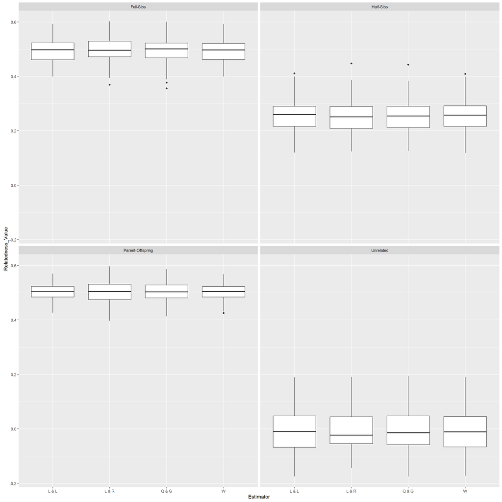

You can see there is not alot of difference between these estimators - at least with this number of loci.

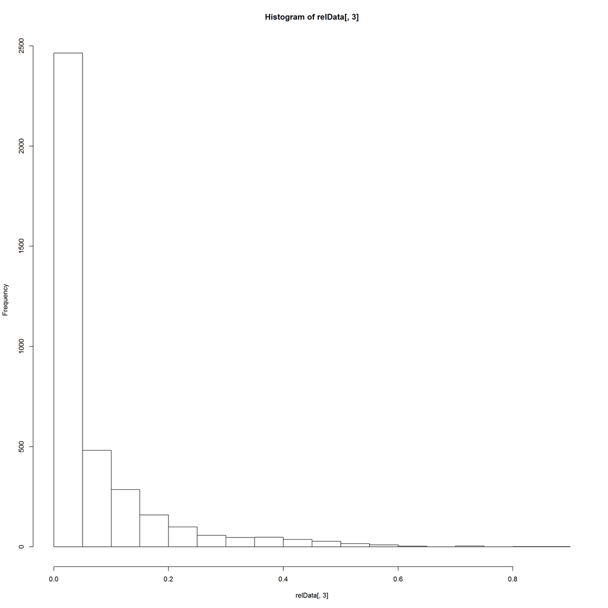

```r
require(igraph)
relData <- output$relatedness[, c(2, 3, 11)]
hist(relData[, 3])
```

```r
lrelData <- relData
colnames(lrelData)[1] <- "from"
colnames(lrelData)[2] <- "to"
colnames(lrelData)[3] <- "weight"
lrelData$type <- "probRel"
relDataNoRows <- nrow(relData)
nrelData <- data.frame(matrix(ncol = 4, nrow = relDataNoRows))
colnames(nrelData) <- c("id", "name", "type", "label")
nrelData[, 1] <- relData[, 2]
nrelData[, 2] <- relData[, 2]
newrow = c(relData[1, 1], relData[1, 1], NA, NA)
nrelData = rbind(nrelData, newrow)
nrow(nrelData)
```

```
## [1] 3742
```

```r
length(unique(nrelData$id))
```

```
## [1] 87
```

```r
nrow(lrelData)
```

```
## [1] 3741
```

```r
nrow(unique(lrelData[, c("from", "to")]))
```

```
## [1] 3741
```

```r
nrelData <- data.frame(unique(nrelData[, 1:4]))
tst <- ifelse(grepl("^A", nrelData$id), nrelData$type <- "adult", nrelData$type <- "larvae")
nrelData$type <- tst
rm(tst)
larvNrel <- merge(nrelData, larv, by.x = "id", by.y = "LarvalRecords_LarvaID")
larvNrel <- larvNrel[, c(1:4, 66)]
head(nrelData)
```

```
##   id name   type label
## 1 71   71 larvae  <NA>
## 2 72   72 larvae  <NA>
## 3 73   73 larvae  <NA>
## 4 76   76 larvae  <NA>
## 5 75   75 larvae  <NA>
## 6 74   74 larvae  <NA>
```

```r
head(larvNrel)
```

```
##    id name   type label YearOnly
## 1 100  100 larvae  <NA>     2011
## 2 101  101 larvae  <NA>     2011
## 3 103  103 larvae  <NA>     2011
## 4 104  104 larvae  <NA>     2011
## 5 105  105 larvae  <NA>     2011
## 6 107  107 larvae  <NA>     2011
```

```r
net <- graph_from_data_frame(d = lrelData, vertices = nrelData, directed = FALSE)
```

## Plot relationships

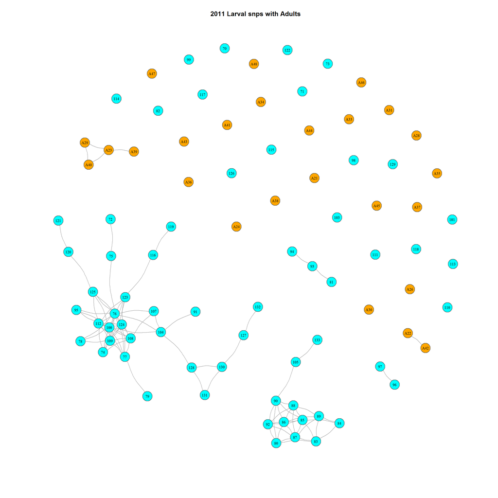

```r
#Limit to full siblings - this also makes it more sparse.
net.FS <- delete_edges(net, E(net)[weight<0.4])
l <- layout_with_fr(net.FS)

plot(net.FS, edge.arrow.size=0, edge.curved=0.2, vertex.size=5,vertex.color=c("orange", "cyan")[(V(net.FS)$type=="larvae")+1], vertex.frame.color="#555555",vertex.label=V(net)$name, vertex.label.color="black",vertex.label.cex=.7,layout=l, main = main)
```

# 2012 Larval with Adult Relatedness

```r
#read file in
twAdLarv<-cbind(twlarvalPeeliSnps,adultPeeliSnps)
df<-twAdLarv; main<-"2012 Larval snps with Adults"
df<-df[-c(1:4),]
```

```r
require(digest)
for (i in 1:length(df$X..2)) {
    df$unique[i] <- digest(df$X..2[i], algo = "xxhash32", seed = 1)
}
df <- cbind(df$unique, df)
names(df)[names(df) == "df$unique"] <- "allele"
df$unique <- NULL
df[1:10, c(1, 4)]
```

```
##       allele                                                                  X..2
## X5  a43f66cc                                                        AlleleSequence
## X6  127f06ec TGCAGGAGTCACGTTTCTCTCCCAAAACTCCCCTTAAGCTAAAAAACGTATAAATGAGAGCGTCAGCTA
## X7  756ac72f TGCAGGAGTCACGTTTCTCTCCCAAAACTCCCCTTAAGCTAAAAAACGTATAAATGAGAGTGTCAGCTA
## X8  648bd84a TGCAGAAATAAAGAACTTATTTTCAACCAACATGTCTTGTGATACCAAAGTTCTTTGGCCGCTATGTGC
## X9  9e1e8afc TGCAGAAATAAAGAATTTATTTTCAACCAACATGTCTTGTGATACCAAAGTTCTTTGGCCGCTATGTGC
## X10 d1899d1e TGCAGTGCTAATGCAGTTCGGAGGGCTTCTGCAATGCCTGTAAATGTGTACATGAGTATGTTTGTACAC
## X11 1beb420d TGCAGTGCTAATGCAGTTCGGGGGGCTTCTGCAATGCCTGTAAATGTGTACATGAGTATGTTTGTACAC
## X12 6a38a8f3 TGCAGTTGGACCCTTTGGTTGCCATTAGCCACGCTATCGTTTACTCCAGCTTTCCAAAACTGGGAAAGC
## X13 2630df0b TGCAGTTGGACCCTTTGGTTGCCATTAGCCACGCTATCGTTTACTCCAGCTTTCCAAAACTGGAAAAGC
## X14 c58a8999 TGCAGTTAACTCACCAAACTTTACTTTCCCACATTCCTAAAACCCCAGGCATTTGCATTATTTGAACCC
```

```r
df2 <- df
df2[2:18] <- list(NULL)
df2 <- setNames(data.frame(t(df2[, -1])), df2[, 1])
rownames(df2) <- df2[, 1]
fishID <- df2[, 1]
df2[, 1] <- NULL
colnames(df2) <- paste("X", colnames(df2), sep = "")
df2 <- as.data.frame(apply(df2, 2, function(x) gsub("\\s+", "", x)))
indx <- sapply(df2, is.factor)
df2[indx] <- lapply(df2[indx], function(x) as.numeric(as.character(x)))
rm(indx)
x <- df2
library(data.table)
setDT(x)
for (j in seq_along(x)) {
    set(x, i = which(x[[j]] == 1 & !is.na(x[[j]])), j = j, value = j)
}
d1 <- data.frame(x)
rm(x)
rm(i)
rm(j)
d1.lst <- lapply(seq(1, ncol(d1), by = 2), function(x) {
    return(d1[, x:(x + 1)])
})
d1.lst.fil <- lapply(d1.lst, function(x) {
    x[, 1][!is.na(x[, 1]) & x[, 1] == "0"] <- x[, 2][!is.na(x[, 1]) & x[, 1] == "0"]
    x[, 2][!is.na(x[, 2]) & x[, 2] == "0"] <- x[, 1][!is.na(x[, 2]) & x[, 2] == "0"]
    return(x)
})
df2 <- do.call(cbind, d1.lst.fil)
rm(d1)
rm(d1.lst)
rm(d1.lst.fil)
df2 <- cbind(fishID, df2)
rownames(df2) <- df2[, 1]
df2[, 1] <- NULL
write.table(df2[, 1:600], "outRelated.txt", sep = " ", col.names = FALSE, row.names = TRUE, quote = FALSE)
require(related)
input <- readgenotypedata("outRelated.txt")
input$nloci
```

```
## [1] 300
```

```r
input$nalleles
```

```
##   [1] 2 2 2 2 2 2 2 2 2 2 2 2 2 2 2 2 2 2 2 2 2 2 2 2 2 2 2 2 2 2 2 2 2 2 2 2 2 2 2 2 2 2 2 2 2 2 2 2 2 2 2 2 2 2 2 2 2 2 2 2 2 2 2 2 2 2 2 2 2 2 2 2 2 2 2 2 2 2 2 2 2 2 2 2 2 2 2 2 2 2 2 2 2 2 2 2 2
##  [98] 2 2 2 2 2 2 2 2 2 2 2 2 2 2 2 2 2 2 2 2 2 2 2 2 2 2 2 2 2 2 2 2 2 2 2 2 2 2 2 2 2 2 2 2 2 2 2 2 2 2 2 2 2 2 2 2 2 2 2 2 2 2 2 2 2 2 2 2 2 2 2 2 2 2 2 2 2 2 2 2 2 2 2 2 2 2 2 2 2 2 2 2 2 2 2 2 2
## [195] 2 2 2 2 2 2 2 2 2 2 2 2 2 2 2 2 2 2 2 2 2 2 2 2 2 2 2 2 2 2 2 2 2 2 2 2 2 2 2 2 2 2 2 2 2 2 2 2 2 2 2 2 2 2 2 2 2 2 2 2 2 2 2 2 2 2 2 2 2 2 2 2 2 2 2 2 2 2 2 2 2 2 2 2 2 2 2 2 2 2 2 2 2 2 2 2 2
## [292] 2 2 2 2 2 2 2 2 2
```

```r
input$ninds
```

```
## [1] 71
```

```r
output <- coancestry(input$gdata, allow.inbreeding = TRUE, dyadml = 2)
```

```
##    user  system elapsed
##   67.62    0.30   70.17
##
## Reading output files into data.frames... Done!
```

```r
head(output$relatedness)
```

```
##   pair.no ind1.id ind2.id group trioml wang lynchli lynchrd ritland quellergt dyadml
## 1       1     134     151  1315      0    0       0       0       0         0 0.1323
## 2       2     134     157  1315      0    0       0       0       0         0 0.0000
## 3       3     134     156  1315      0    0       0       0       0         0 0.0403
## 4       4     134     155  1315      0    0       0       0       0         0 0.0955
## 5       5     134     154  1315      0    0       0       0       0         0 0.0000
## 6       6     134     153  1315      0    0       0       0       0         0 0.0000
```

```r
head(output$inbreeding)
```

```
##   ind.id      LH      LR
## 1    134 -0.5699 -0.4935
## 2    151 -0.3510 -0.3341
## 3    157  0.0770  0.0834
## 4    156 -0.1157 -0.1227
## 5    155 -0.0808 -0.0824
## 6    154 -0.0905 -0.1042
```

```r
sim <- familysim(input$freqs, 100)
output2 <- coancestry(sim, wang = 1)
```

```
##    user  system elapsed
##  119.78   16.74  203.19
##
## Reading output files into data.frames... Done!
```

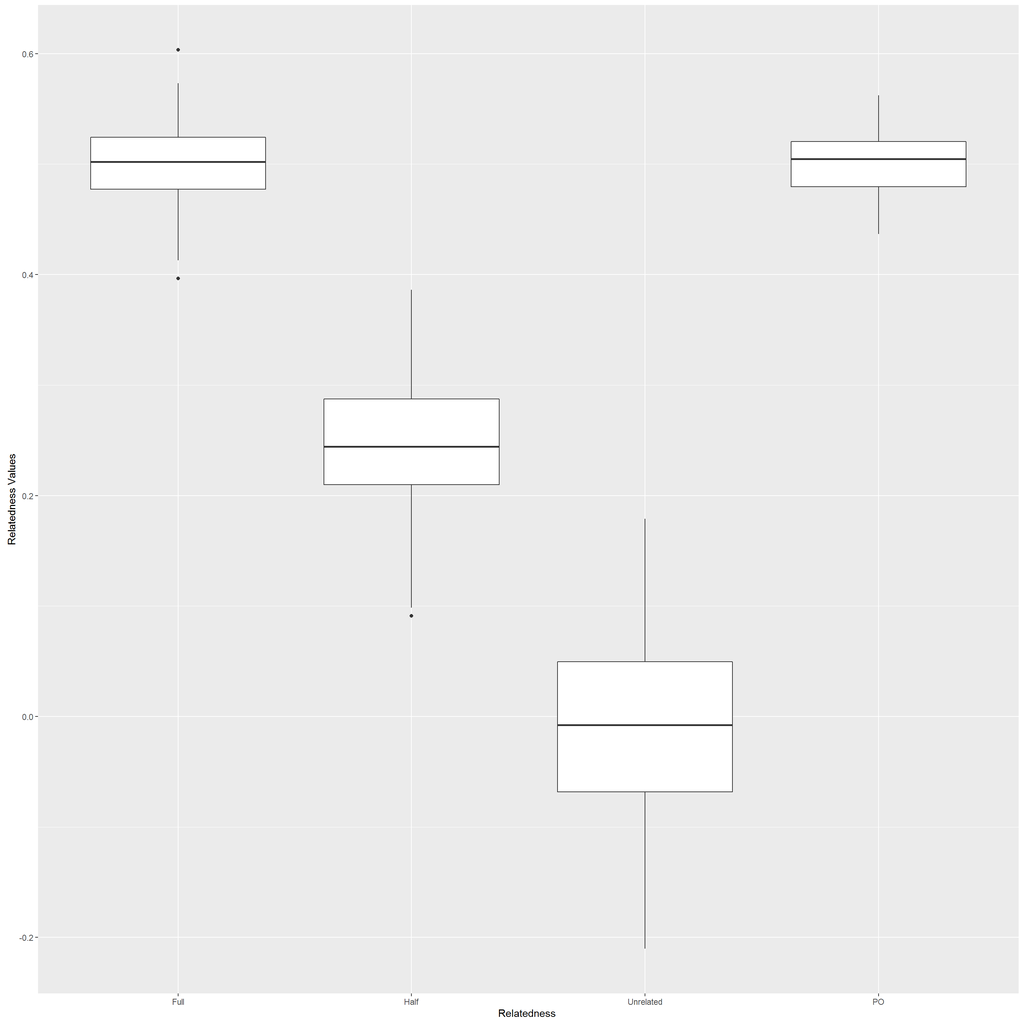

```r
simrel <- cleanuprvals(output2$relatedness, 100)
relvalues <- simrel[, 6]
label1 <- rep("PO", 100)
label2 <- rep(" Full ", 100)
label3 <- rep(" Half ", 100)
label4 <- rep(" Unrelated ", 100)
labels <- c(label1, label2, label3, label4)
qplot(as.factor(labels), relvalues, geom = "boxplot", ylab = " Relatedness Values ", xlab = "Relatedness ")
```

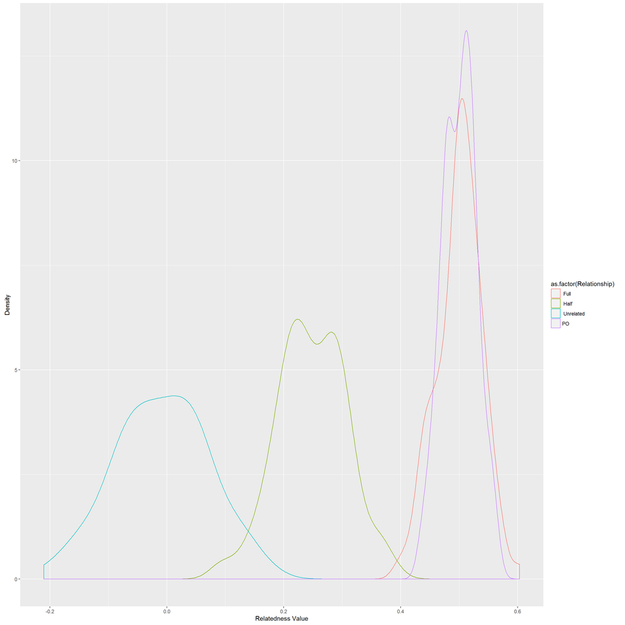

```r
Relationship <- labels
newdata <- as.data.frame(cbind(Relationship, relvalues))
newdata$relvalues <- as.numeric(as.character(newdata$relvalues))
qplot(relvalues, ..density.., data = newdata, geom = "density", colour = as.factor(Relationship), xlab = " Relatedness Value ", ylab = "Density")
```

So there are 300 loci being analysed. These are the first loci in the file ATM.

There are 2 alleles for each of these loci.

There are 71 individual fish in this set. From the simulations of ‘known’ relationships we can choose cut off values for identifying relationships and colouring them in the matrix. In this case FS or PO above 0.4; HS 0.1-0.4; unrelated fish have a relatedness value below 0.15.

## Compare Estimators

```r
compareestimators(input, 100)
```

```
##    user  system elapsed
##  137.92   17.05  221.39
##
## Reading output files into data.frames... Done!
##
## Correlation Coefficients Between Observed & Expected Values:
## wang     0.965518
## lynchli      0.965654
## lynchrd      0.970173
## quellergt    0.968131
```

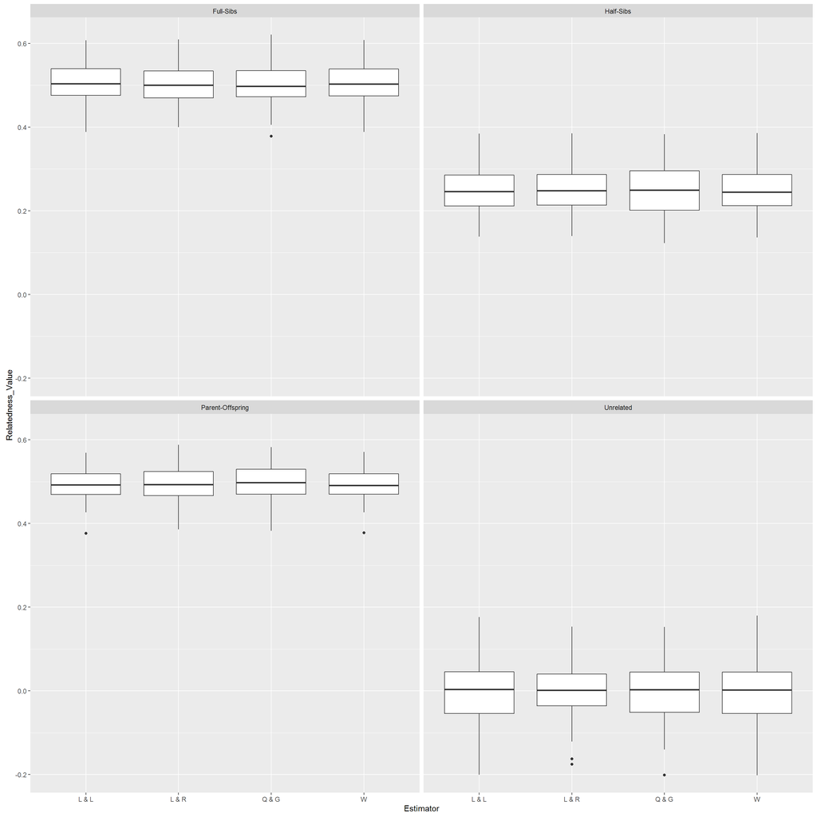

You can see there is not alot of difference between these estimators - at least with this number of loci.

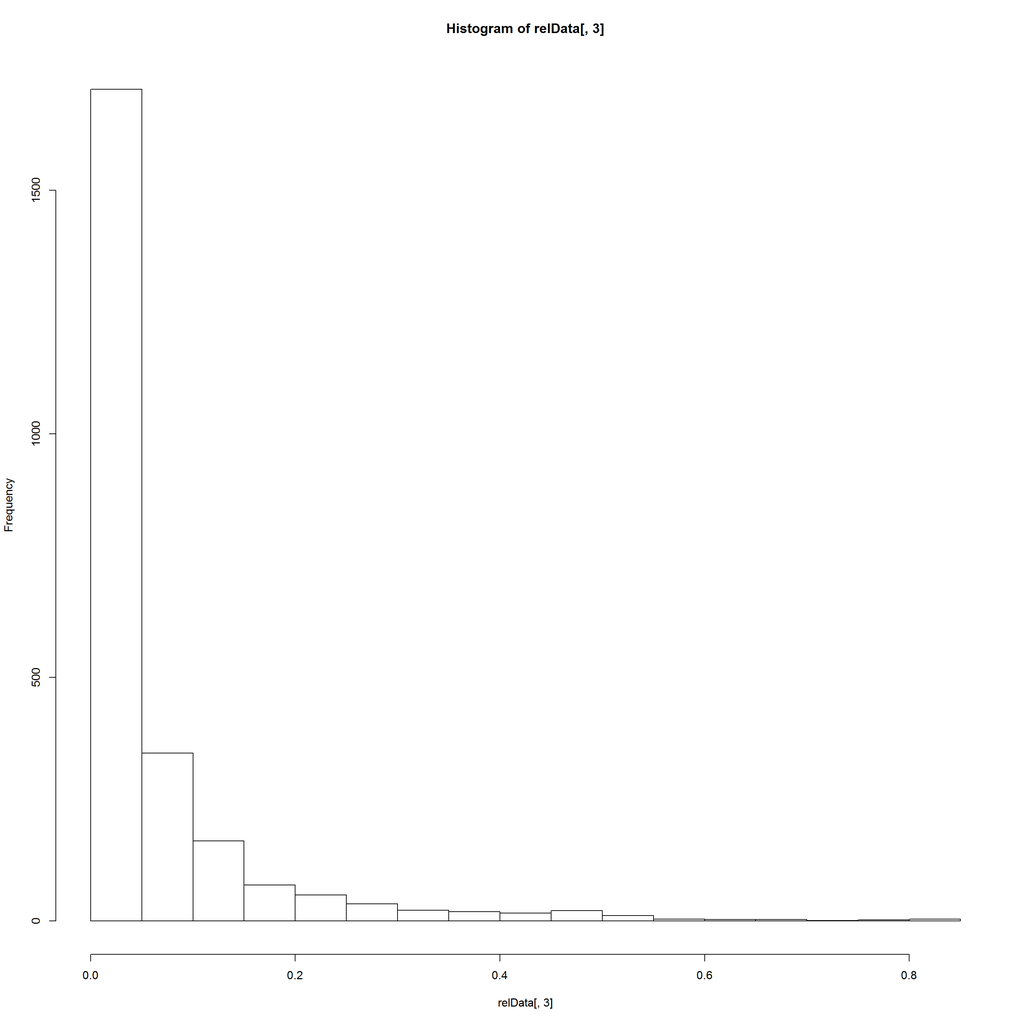

```r
require(igraph)
relData <- output$relatedness[, c(2, 3, 11)]
hist(relData[, 3])
```

```r
lrelData <- relData
colnames(lrelData)[1] <- "from"
colnames(lrelData)[2] <- "to"
colnames(lrelData)[3] <- "weight"
lrelData$type <- "probRel"
relDataNoRows <- nrow(relData)
nrelData <- data.frame(matrix(ncol = 4, nrow = relDataNoRows))
colnames(nrelData) <- c("id", "name", "type", "label")
nrelData[, 1] <- relData[, 2]
nrelData[, 2] <- relData[, 2]
newrow = c(relData[1, 1], relData[1, 1], NA, NA)
nrelData = rbind(nrelData, newrow)
nrow(nrelData)
```

```
## [1] 2486
```

```r
length(unique(nrelData$id))
```

```
## [1] 71
```

```r
nrow(lrelData)
```

```
## [1] 2485
```

```r
nrow(unique(lrelData[, c("from", "to")]))
```

```
## [1] 2485
```

```r
nrelData <- data.frame(unique(nrelData[, 1:4]))
tst <- ifelse(grepl("^A", nrelData$id), nrelData$type <- "adult", nrelData$type <- "larvae")
nrelData$type <- tst
rm(tst)
larvNrel <- merge(nrelData, larv, by.x = "id", by.y = "LarvalRecords_LarvaID")
larvNrel <- larvNrel[, c(1:4, 66)]
head(nrelData)
```

```
##    id name   type label
## 1 151  151 larvae  <NA>
## 2 157  157 larvae  <NA>
## 3 156  156 larvae  <NA>
## 4 155  155 larvae  <NA>
## 5 154  154 larvae  <NA>
## 6 153  153 larvae  <NA>
```

```r
head(larvNrel)
```

```
##    id name   type label YearOnly
## 1 134  134 larvae  <NA>     2012
## 2 135  135 larvae  <NA>     2012
## 3 136  136 larvae  <NA>     2012
## 4 137  137 larvae  <NA>     2012
## 5 138  138 larvae  <NA>     2012
## 6 139  139 larvae  <NA>     2012
```

```r
net <- graph_from_data_frame(d = lrelData, vertices = nrelData, directed = FALSE)
```

## Plot relationships

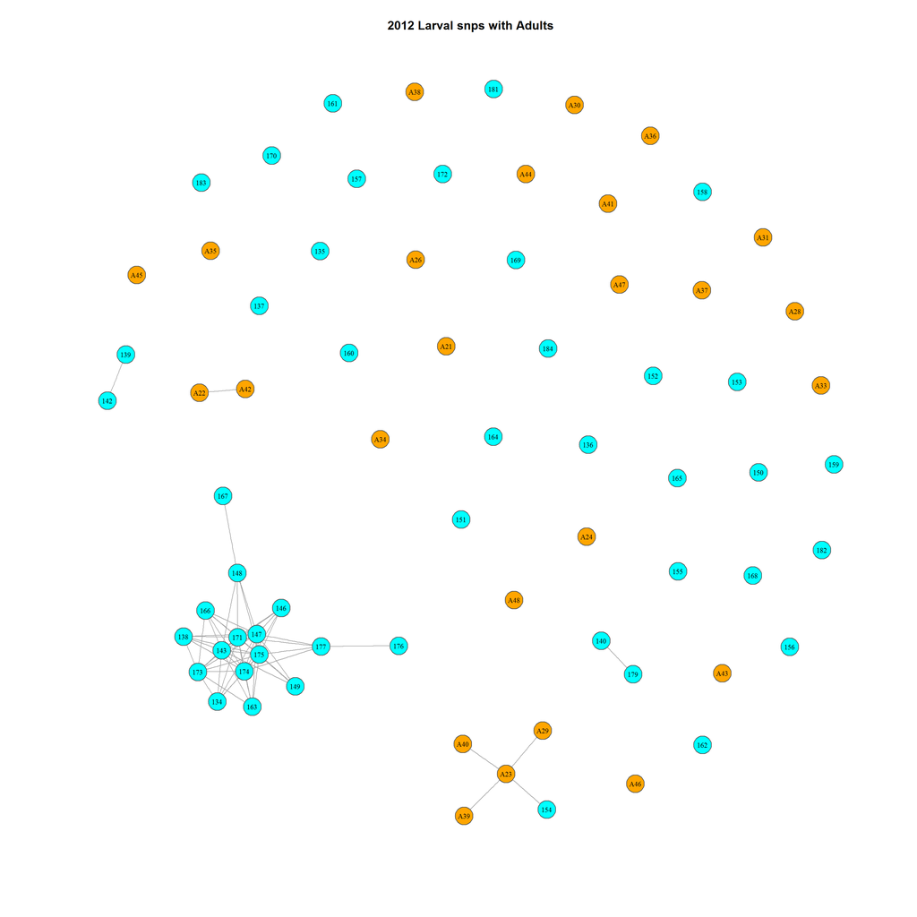

```r
#Limit to full siblings - this also makes it more sparse.
net.FS <- delete_edges(net, E(net)[weight<0.4])
l <- layout_with_fr(net.FS)

plot(net.FS, edge.arrow.size=0, edge.curved=0, vertex.size=5,vertex.color=c("orange", "cyan")[(V(net.FS)$type=="larvae")+1], vertex.frame.color="#555555",vertex.label=V(net)$name, vertex.label.color="black",vertex.label.cex=.7,layout=l, main = main)
```

# 2013 Larval with Adult Relatedness

```r
#read file in
thAdLarv<-cbind(thlarvalPeeliSnps,adultPeeliSnps)
df<-thAdLarv; main<-"2013 Larval snps with Adults"
df<-df[-c(1:4),]
```

```r
require(digest)
for (i in 1:length(df$X..2)) {
    df$unique[i] <- digest(df$X..2[i], algo = "xxhash32", seed = 1)
}
df <- cbind(df$unique, df)
names(df)[names(df) == "df$unique"] <- "allele"
df$unique <- NULL
df[1:10, c(1, 4)]
```

```
##       allele                                                                  X..2
## X5  a43f66cc                                                        AlleleSequence
## X6  127f06ec TGCAGGAGTCACGTTTCTCTCCCAAAACTCCCCTTAAGCTAAAAAACGTATAAATGAGAGCGTCAGCTA
## X7  756ac72f TGCAGGAGTCACGTTTCTCTCCCAAAACTCCCCTTAAGCTAAAAAACGTATAAATGAGAGTGTCAGCTA
## X8  648bd84a TGCAGAAATAAAGAACTTATTTTCAACCAACATGTCTTGTGATACCAAAGTTCTTTGGCCGCTATGTGC
## X9  9e1e8afc TGCAGAAATAAAGAATTTATTTTCAACCAACATGTCTTGTGATACCAAAGTTCTTTGGCCGCTATGTGC
## X10 d1899d1e TGCAGTGCTAATGCAGTTCGGAGGGCTTCTGCAATGCCTGTAAATGTGTACATGAGTATGTTTGTACAC
## X11 1beb420d TGCAGTGCTAATGCAGTTCGGGGGGCTTCTGCAATGCCTGTAAATGTGTACATGAGTATGTTTGTACAC
## X12 6a38a8f3 TGCAGTTGGACCCTTTGGTTGCCATTAGCCACGCTATCGTTTACTCCAGCTTTCCAAAACTGGGAAAGC
## X13 2630df0b TGCAGTTGGACCCTTTGGTTGCCATTAGCCACGCTATCGTTTACTCCAGCTTTCCAAAACTGGAAAAGC
## X14 c58a8999 TGCAGTTAACTCACCAAACTTTACTTTCCCACATTCCTAAAACCCCAGGCATTTGCATTATTTGAACCC
```

```r
df2 <- df
df2[2:18] <- list(NULL)
df2 <- setNames(data.frame(t(df2[, -1])), df2[, 1])
rownames(df2) <- df2[, 1]
fishID <- df2[, 1]
df2[, 1] <- NULL
colnames(df2) <- paste("X", colnames(df2), sep = "")
df2 <- as.data.frame(apply(df2, 2, function(x) gsub("\\s+", "", x)))
indx <- sapply(df2, is.factor)
df2[indx] <- lapply(df2[indx], function(x) as.numeric(as.character(x)))
rm(indx)
x <- df2
library(data.table)
setDT(x)
for (j in seq_along(x)) {
    set(x, i = which(x[[j]] == 1 & !is.na(x[[j]])), j = j, value = j)
}
d1 <- data.frame(x)
rm(x)
rm(i)
rm(j)
d1.lst <- lapply(seq(1, ncol(d1), by = 2), function(x) {
    return(d1[, x:(x + 1)])
})
d1.lst.fil <- lapply(d1.lst, function(x) {
    x[, 1][!is.na(x[, 1]) & x[, 1] == "0"] <- x[, 2][!is.na(x[, 1]) & x[, 1] == "0"]
    x[, 2][!is.na(x[, 2]) & x[, 2] == "0"] <- x[, 1][!is.na(x[, 2]) & x[, 2] == "0"]
    return(x)
})
df2 <- do.call(cbind, d1.lst.fil)
rm(d1)
rm(d1.lst)
rm(d1.lst.fil)
df2 <- cbind(fishID, df2)
rownames(df2) <- df2[, 1]
df2[, 1] <- NULL
write.table(df2[, 1:600], "outRelated.txt", sep = " ", col.names = FALSE, row.names = TRUE, quote = FALSE)
require(related)
input <- readgenotypedata("outRelated.txt")
input$nloci
```

```
## [1] 300
```

```r
input$nalleles
```

```
##   [1] 2 2 2 2 2 2 2 2 2 2 2 2 2 2 2 2 2 2 2 2 2 2 2 2 2 2 2 2 2 2 2 2 2 2 2 2 2 2 2 2 2 2 2 2 2 2 2 2 2 2 2 2 2 2 2 2 2 2 2 2 2 2 2 2 2 2 2 2 2 2 2 2 2 2 2 2 2 2 2 2 2 2 2 2 2 2 2 2 2 2 2 2 2 2 2 2 2
##  [98] 2 2 2 2 2 2 2 2 2 2 2 2 2 2 2 2 2 2 2 2 2 2 2 2 2 2 2 2 2 2 2 2 2 2 2 2 2 2 2 2 2 2 2 2 2 2 2 2 2 2 2 2 2 2 2 2 2 2 2 2 2 2 2 2 2 2 2 2 2 2 2 2 2 2 2 2 2 2 2 2 2 2 2 2 2 2 2 2 2 2 2 2 2 2 2 2 2
## [195] 2 2 2 2 2 2 2 2 2 2 2 2 2 2 2 2 2 2 2 2 2 2 2 2 2 2 2 2 2 2 2 2 2 2 2 2 2 2 2 2 2 2 2 2 2 2 2 2 2 2 2 2 2 2 2 2 2 2 2 2 2 2 2 2 2 2 2 2 2 2 2 2 2 2 2 2 2 2 2 2 2 2 2 2 2 2 2 2 2 2 2 2 2 2 2 2 2
## [292] 2 2 2 2 2 2 2 2 2
```

```r
input$ninds
```

```
## [1] 160
```

```r
output <- coancestry(input$gdata, allow.inbreeding = TRUE, dyadml = 2)
```

```
##    user  system elapsed
##  364.65    1.25  375.20
##
## Reading output files into data.frames... Done!
```

```r
head(output$relatedness)
```

```
##   pair.no ind1.id ind2.id group trioml wang lynchli lynchrd ritland quellergt dyadml
## 1       1     185     186  1818      0    0       0       0       0         0 0.4618
## 2       2     185     187  1818      0    0       0       0       0         0 0.4458
## 3       3     185     188  1818      0    0       0       0       0         0 0.2814
## 4       4     185     189  1818      0    0       0       0       0         0 0.4827
## 5       5     185     190  1819      0    0       0       0       0         0 0.4470
## 6       6     185     191  1819      0    0       0       0       0         0 0.0000
```

```r
head(output$inbreeding)
```

```
##   ind.id      LH      LR
## 1    185  0.0195  0.0208
## 2    186 -0.0029 -0.0030
## 3    187  0.0847  0.0869
## 4    188 -0.0107 -0.0108
## 5    189  0.0628  0.0645
## 6    190 -0.0156 -0.0170
```

```r
sim <- familysim(input$freqs, 100)
output2 <- coancestry(sim, wang = 1)
```

```
##    user  system elapsed
##  130.08   17.78  219.23
##
## Reading output files into data.frames... Done!
```

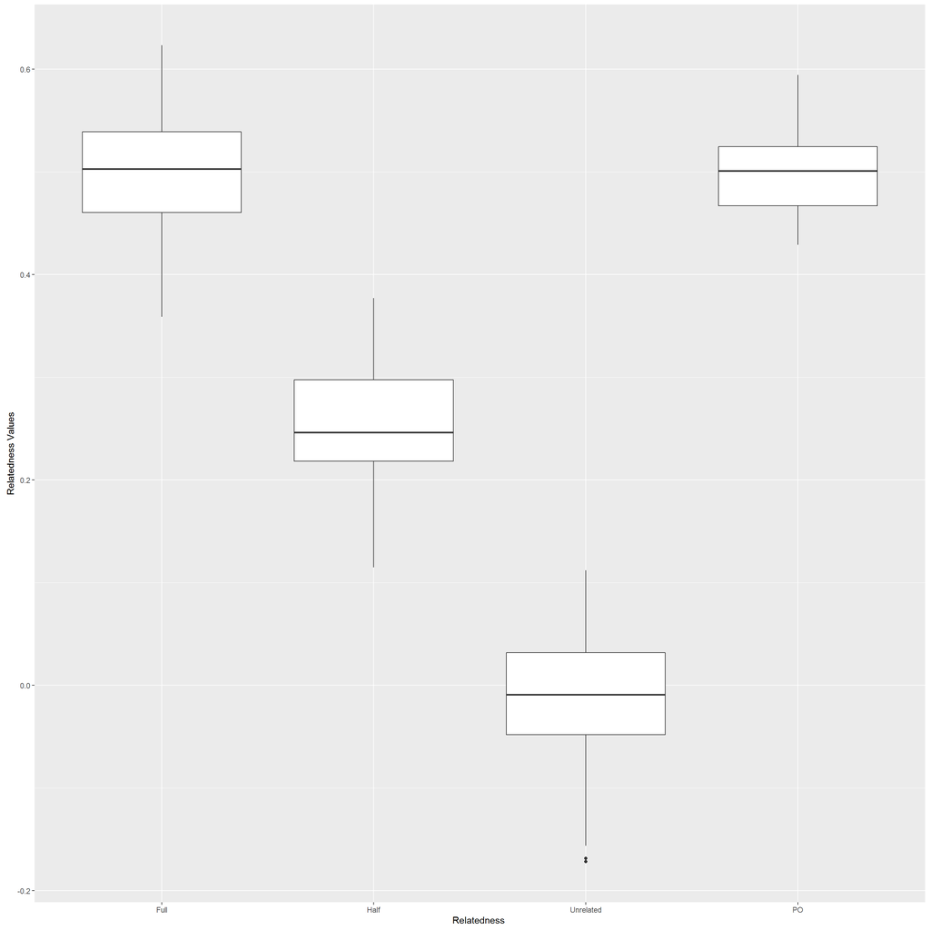

```r
simrel <- cleanuprvals(output2$relatedness, 100)
relvalues <- simrel[, 6]
label1 <- rep("PO", 100)
label2 <- rep(" Full ", 100)
label3 <- rep(" Half ", 100)
label4 <- rep(" Unrelated ", 100)
labels <- c(label1, label2, label3, label4)
qplot(as.factor(labels), relvalues, geom = "boxplot", ylab = " Relatedness Values ", xlab = "Relatedness ")
```

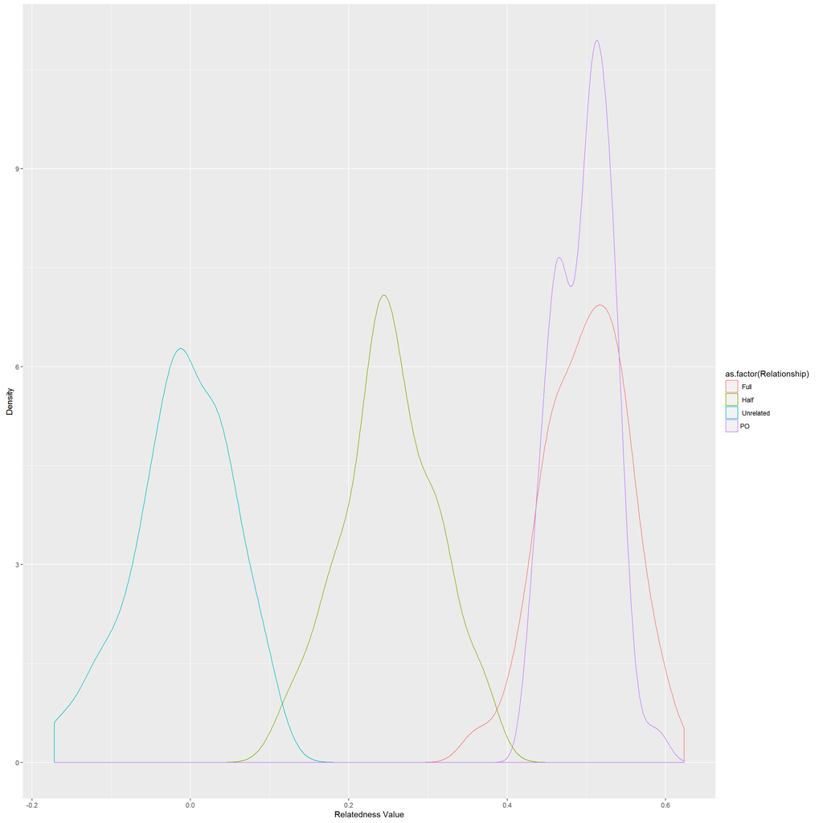

```r
Relationship <- labels
newdata <- as.data.frame(cbind(Relationship, relvalues))
newdata$relvalues <- as.numeric(as.character(newdata$relvalues))
qplot(relvalues, ..density.., data = newdata, geom = "density", colour = as.factor(Relationship), xlab = " Relatedness Value ", ylab = "Density")
```

So there are 300 loci being analysed. These are the first loci in the file ATM.

There are 2 alleles for each of these loci.

There are 160 individual fish in this set. From the simulations of ‘known’ relationships we can choose cut off values for identifying relationships and colouring them in the matrix. In this case FS or PO above 0.4; HS 0.1-0.4; unrelated fish have a relatedness value below 0.15.

## Compare Estimators

```r
compareestimators(input, 100)
```

```
##    user  system elapsed
##  141.93   17.51  229.32
##
## Reading output files into data.frames... Done!
##
## Correlation Coefficients Between Observed & Expected Values:
## wang     0.965848
## lynchli      0.966017
## lynchrd      0.972254
## quellergt    0.970908
```

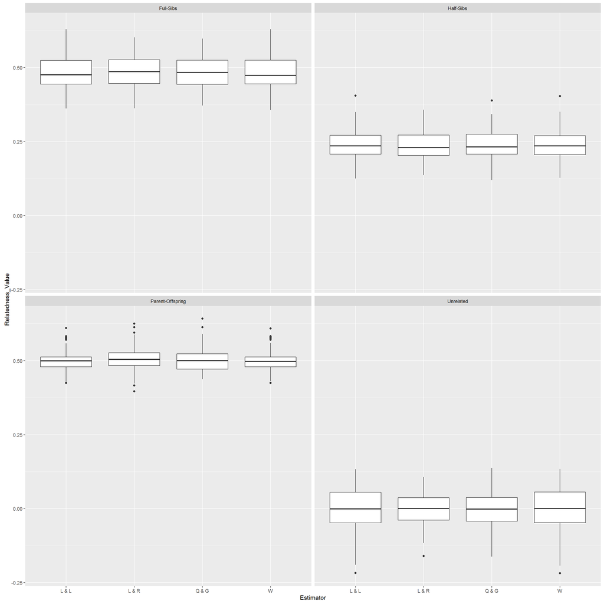

You can see there is not alot of difference between these estimators - at least with this number of loci.

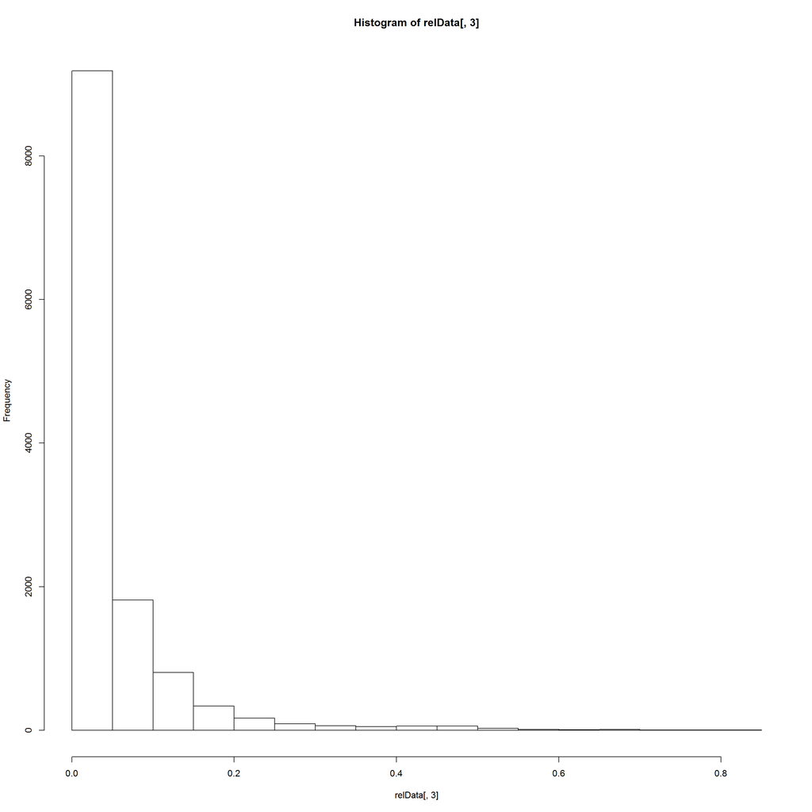

```r
require(igraph)
relData <- output$relatedness[, c(2, 3, 11)]
hist(relData[, 3])
```

```r
lrelData <- relData
colnames(lrelData)[1] <- "from"
colnames(lrelData)[2] <- "to"
colnames(lrelData)[3] <- "weight"
lrelData$type <- "probRel"
relDataNoRows <- nrow(relData)
nrelData <- data.frame(matrix(ncol = 4, nrow = relDataNoRows))
colnames(nrelData) <- c("id", "name", "type", "label")
nrelData[, 1] <- relData[, 2]
nrelData[, 2] <- relData[, 2]
newrow = c(relData[1, 1], relData[1, 1], NA, NA)
nrelData = rbind(nrelData, newrow)
nrow(nrelData)
```

```
## [1] 12721
```

```r
length(unique(nrelData$id))
```

```
## [1] 160
```

```r
nrow(lrelData)
```

```
## [1] 12720
```

```r
nrow(unique(lrelData[, c("from", "to")]))
```

```
## [1] 12720
```

```r
nrelData <- data.frame(unique(nrelData[, 1:4]))
tst <- ifelse(grepl("^A", nrelData$id), nrelData$type <- "adult", nrelData$type <- "larvae")
nrelData$type <- tst
rm(tst)
larvNrel <- merge(nrelData, larv, by.x = "id", by.y = "LarvalRecords_LarvaID")
larvNrel <- larvNrel[, c(1:4, 66)]
head(nrelData)
```

```
##    id name   type label
## 1 186  186 larvae  <NA>
## 2 187  187 larvae  <NA>
## 3 188  188 larvae  <NA>
## 4 189  189 larvae  <NA>
## 5 190  190 larvae  <NA>
## 6 191  191 larvae  <NA>
```

```r
head(larvNrel)
```

```
##    id name   type label YearOnly
## 1 185  185 larvae  <NA>     2013
## 2 186  186 larvae  <NA>     2013
## 3 187  187 larvae  <NA>     2013
## 4 188  188 larvae  <NA>     2013
## 5 189  189 larvae  <NA>     2013
## 6 190  190 larvae  <NA>     2013
```

```r
net <- graph_from_data_frame(d = lrelData, vertices = nrelData, directed = FALSE)
```

## Plot relationships

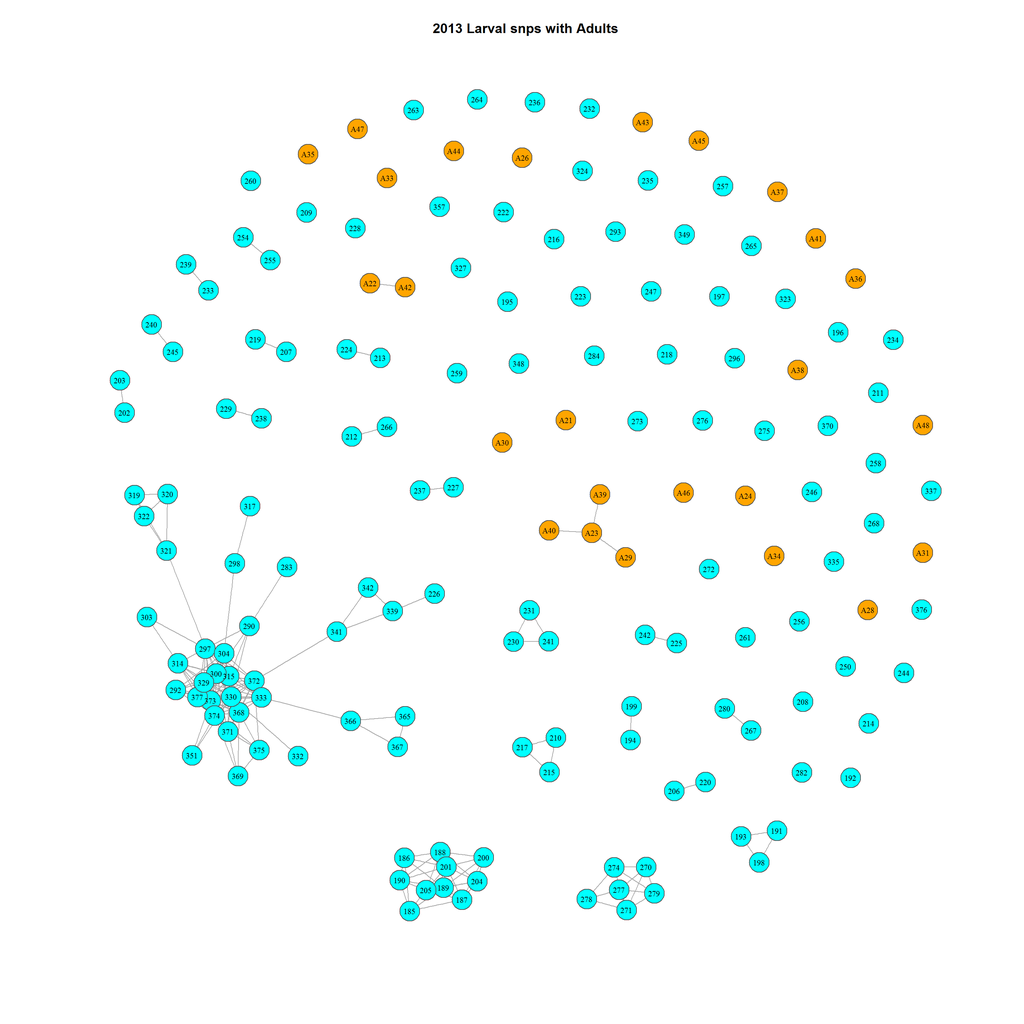

```r
#Limit to full siblings - this also makes it more sparse.
net.FS <- delete_edges(net, E(net)[weight<0.4])
l <- layout_with_fr(net.FS)

plot(net.FS, edge.arrow.size=0, edge.curved=0, vertex.size=5,vertex.color=c("orange", "cyan")[(V(net.FS)$type=="larvae")+1], vertex.frame.color="#555555",vertex.label=V(net)$name, vertex.label.color="black",vertex.label.cex=.7,layout=l, main = main)
```

```r
all_labels()
```

```
##  [1] "Project_Template_and_Knitr"                      "Set_Global_Options"                              "unnamed-chunk-1"
##  [4] "unnamed-chunk-2"                                 "Sibling Relationships in 2011 Larvae and Adults" "Larvae2011"
##  [7] "Larvae2011Estimators"                            "Larvae2011Net"                                   "unnamed-chunk-3"
## [10] "Sibling Relationships in 2012 Larvae and Adults" "Larvae2012"                                      "Larvae2012Estimators"
## [13] "Larvae2012Net"                                   "unnamed-chunk-4"                                 "Sibling Relationships in 2013 Larvae and Adults"
## [16] "Larvae2013"                                      "Larvae2013Estimators"                            "Larvae2013Net"
## [19] "unnamed-chunk-5"                                 "Include_Chunk_Labels_and_Session Information"    "related"
## [22] "createNetA"                                      "compareRelEstimators"
```

```r
proc.time()-ptm
```

```
##    user  system elapsed
## 1578.20  129.47 2167.03
```